# School level innovation

Tony Daza

2023-05-18

**Importing Data**

```r
central_network <- full %>% select(c(2,3,5,6,7, 9:16, 131:132, 156, 165:167, 213:215, 224:244, 281:285))
```

# Correlation of Central Practices

Correlations of Central Practices for schools with Innovation Network.

```r
# THIS SHOULD NOT BE HERE BUT THE FILE WOULD NOT KNIT OTHERWISE
central_cor <- central_network %>%
  filter(central_network$innovation_initiative == 1) %>%  # & central_network$innovation_initiative_importance != "NA") %>%
  select(c(23:25, 27, 30:33))

# Column 21 is the importance question

central_cor_mat <- correlate(central_cor)
```

```
## Correlation computed with
## • Method: 'pearson'
## • Missing treated using: 'pairwise.complete.obs'
```

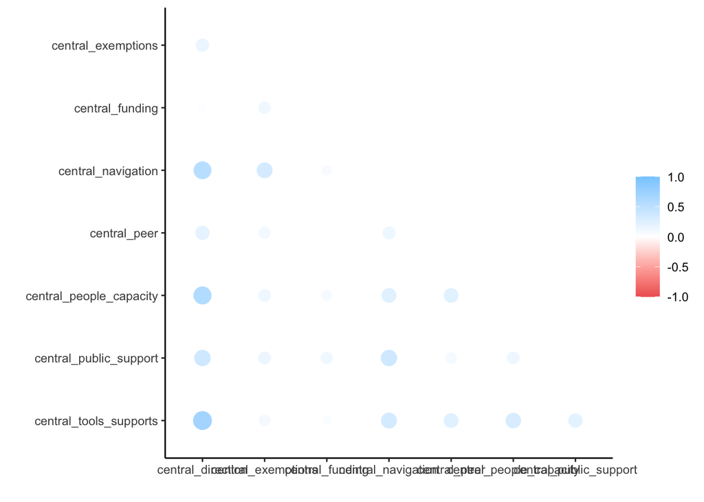

```r
central_cor_mat <- central_cor_mat %>%
  shave(upper = TRUE)

rplot(central_cor_mat)
```

```r
central_cor_mat <- central_cor_mat %>%
  fashion(na_print = "", leading_zeros = TRUE, decimals = 2)
gt(central_cor_mat)
```

| term | central_direction | central_exemptions | central_funding | central_navigation | central_peer | central_people_capacity | central_public_support | central_tools_supports |
| --- | --- | --- | --- | --- | --- | --- | --- | --- |
| central_direction |  |  |  |  |  |  |  |  |
| central_exemptions | 0.33 |  |  |  |  |  |  |  |
| central_funding | 0.15 | 0.30 |  |  |  |  |  |  |
| central_navigation | 0.61 | 0.48 | 0.22 |  |  |  |  |  |
| central_peer | 0.38 | 0.28 | 0.10 | 0.31 |  |  |  |  |
| central_people_capacity | 0.63 | 0.31 | 0.24 | 0.41 | 0.41 |  |  |  |
| central_public_support | 0.51 | 0.32 | 0.29 | 0.51 | 0.25 | 0.30 |  |  |
| central_tools_supports | 0.69 | 0.26 | 0.17 | 0.48 | 0.41 | 0.46 | 0.39 |  |

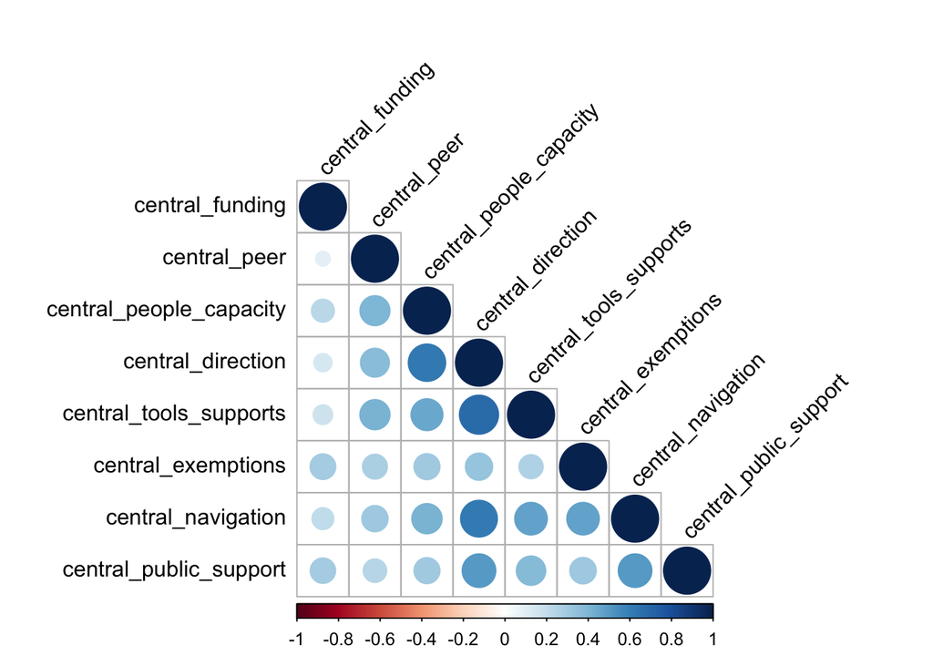

```r
central_cor_mat <- as.matrix(central_cor)

cor_matrix <- rcorr(central_cor_mat)


corrplot(cor_matrix$r, type = "lower", order = "hclust", tl.col = "black", tl.srt = 45)
```

```r
central_network <- central_network %>%
  mutate(central_other =recode(central_other,
                              "1" = as.character(central_other_text)))

central_network <- central_network %>%
  mutate(network_other =recode(network_other,
                              "1" = as.character(network_other_text)))

central_network <- central_network %>%
  mutate(school_descriptor_other =recode(school_descriptor_other,
                              "1" = as.character(school_descriptor_other_text)))

central_network <- central_network %>% select(-c("school_descriptor_other_text", "central_other_text", "network_other_text"))
```

```r
central_cols <- c("central_direction", "central_exemptions", "central_funding", "central_n_a", "central_navigation", "central_peer", "central_people_capacity", "central_public_support", "central_tools_supports")

network_cols <- c("network_direction", "network_exemptions", "network_exemptions", "network_funding", "network_navigation", "network_peer", "network_people_capacity", "network_public_support", "network_tools_supports")
```

# Charter & Public Schools

## Most common central supports

First is a look at the most commonly selected central office supports for public and charter schools.

### All schools

```r
central_percentage <- data.frame(
  name = character(),
  percent_yes = numeric(),
#  percent_no = numeric(),
  stringsAsFactors = FALSE
)

for (i in central_cols){
percent_yes <- round(sum(central_network[[i]])/length(central_network[[i]]) *100,2)

# percent_no <- round((length(school_leap[[i]]) - sum(school_leap[[i]]))/length(school_leap[[i]])*100, 2)

central_percentage <- rbind(central_percentage, data.frame(name = i, percent_yes = percent_yes))

}

gt(central_percentage)
```

| name | percent_yes |
| --- | --- |
| central_direction | 30.28 |
| central_exemptions | 18.33 |
| central_funding | 40.24 |
| central_n_a | 83.27 |
| central_navigation | 37.45 |
| central_peer | 32.27 |
| central_people_capacity | 39.44 |
| central_public_support | 43.43 |
| central_tools_supports | 35.46 |

Most (83%) of public or charter schools nominated indicated that they did receive supports from a central office.

Of those schools, public support and encouragement for the school’s innovative work (43%) and funding (40%) were the most common supports.

The least common supports were exemptions with only 18% of schools reporting central office exemptions from district policies or regulations.

The majority of the supports reported were around 30%.

**Do I need to filter only schools that indicated supports before calculating this?** **I think so.**

### Schools with central office

```r
library(ggplot2)

central_network_yes <- central_network %>%
  filter(central_n_a == 1)

central_cols <- c("central_direction", "central_exemptions", "central_funding", "central_navigation", "central_peer", "central_people_capacity", "central_public_support", "central_tools_supports")

central_percentage <- data.frame(
  name = character(),
  percent_yes = numeric(),
  stringsAsFactors = FALSE
)

for (i in central_cols){
percent_yes <- round(sum(central_network_yes[[i]])/length(central_network_yes[[i]]) *100,2)

central_percentage <- rbind(central_percentage, data.frame(name = i, percent_yes = percent_yes))

}

gt(central_percentage)
```

| name | percent_yes |
| --- | --- |
| central_direction | 36.36 |
| central_exemptions | 22.01 |
| central_funding | 48.33 |
| central_navigation | 44.98 |
| central_peer | 38.76 |
| central_people_capacity | 47.37 |
| central_public_support | 52.15 |
| central_tools_supports | 42.58 |

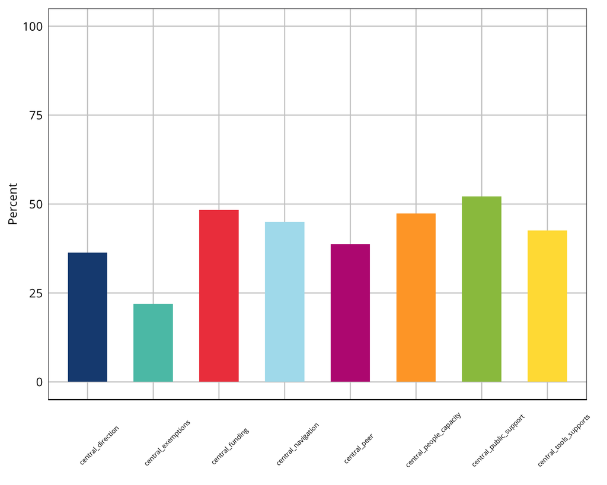

```r
bar_colors <- c("#1A4C81", "#59C3B4", "#EF464B", "#ADE0EE", "#BC2582","#FFA630", "#99C24D", "#FFDE42")  # Color palette for the bars

central_percentage %>%
  ggplot(aes(x=name, y = percent_yes, fill = name))+
  geom_col(show.legend = FALSE) +
  scale_fill_manual(values = bar_colors) +
  ylab("Percent") +
  xlab("")+
  scale_y_continuous(limits = c(0,100), n.breaks = 5)+
  theme(axis.text.x = element_text(angle = 45, vjust = 0.05, hjust = 0.15, size = 8))
```

**This is better**

Of schools that reported central office supports (about 80% of schools) the most common supports were:

Public support of their work 52% Central funding 48% People and time support for innovative project 47%

Least common supports were: District policy or regulatory exemptions 22% Direction and vision for innovative project 36% Peer connections or learning communities 38%

The rest of the supports were about 40%

## Innovation importance

### Pie Charts

How do schools’ responses to the “how important is this initiative” question relate to their responses to the “does your central office provide” question?

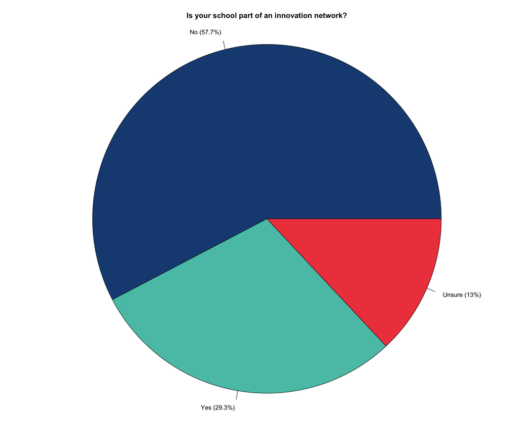

```r
# Number of schools that reported being part of a larger innovation network:
## 0 = No, 1 = Yes, 2 = Not sure
imp_plot <- table(central_network$innovation_initiative)

# Custom character labels
custom_labels <- c("No", "Yes", "Unsure")

# Calculate percentages
percentages <- round(100 * imp_plot / sum(imp_plot), 1)

# Create labels with both custom labels and percentages
labels <- paste0(custom_labels, " (", percentages, "%)")

# Pie chart of schools in an innovation network
pie(imp_plot, radius = 1, col = transcend_cols, labels = labels, main = "Is your school part of an innovation network?")
```

```r
# Proportion of schools responding to the previous question
prop.table(table(central_network$innovation_initiative))
```

```
##
##         0         1         2
## 0.5767442 0.2930233 0.1302326
```

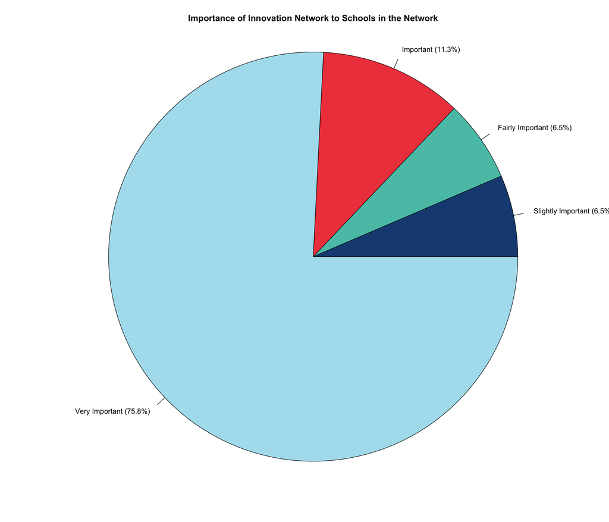

```r
# School responses to the importance of the innovation district/network is to the project
inno_plot <- table(central_network$innovation_initiative_importance)

# Custom character labels
custom_labels <- c("Slightly Important", "Fairly Important", "Important", "Very Important")

# Calculate percentages
percentages <- round(100 * inno_plot / sum(inno_plot), 1)

# Create labels with both custom labels and percentages
labels <- paste0(custom_labels, " (", percentages, "%)")

# Pie Chart for importance of innovation network to schools i nthe network
pie(inno_plot, radius = 1, col = transcend_cols, labels = labels, main = "Importance of Innovation Network to Schools in the Network")
```

```r
# Percentage of responses to the importance question
## Quick note: only schools that responded yes to having a network answered this question

### 1 = not important, 2 = slightly important, 3 = fairly important,
### 4 = important, 5 = very important
prop.table(table(central_network$innovation_initiative_importance))
```

```
##
##          2          3          4          5
## 0.06451613 0.06451613 0.11290323 0.75806452
```

Looking at the innovative importance question, only 62 schools responded. Of those 62 schools, 76% rated the importance as 5 or “very important”. Seven schools, 11%, rated the importance as “important”. The remaining schools, 4 each, were split between “fairly important” and “slightly important” with 6.5% each.

We can examine of the schools that responded to the importance question, what supports did they receive compared to schools that did not respond.

```r
central_network_importance <- central_network %>%
  filter(central_network$innovation_initiative == 1)

# These are the same counts as above, but this is from the data that is filtered to
# only include schools that indicated that they were part of a district network

# The take away here is that only schools that were part of the innovation network responded to the question about importance.

table(central_network_importance$innovation_initiative_importance)
```

```
##
##  2  3  4  5
##  4  4  7 47
```

```r
# Cool so this is all the schools that answered yes to the question:
# Is your learning environment part of a larger innovation initiative within your district or charter network?

# of these schools, we can look at the distribution of supports they received.

table(central_network_importance$central_n_a)
```

```
##
##  0  1
##  5 58
```

```r
# Surprisingly, of these schools, 5 reported not having a central office


central_importance_pct <- data.frame(
  name = character(),
  percent_yes = numeric(),
  stringsAsFactors = FALSE
)

for (i in central_cols){
percent_yes <- round(sum(central_network_importance[[i]])/length(central_network_importance[[i]]) *100,2)

central_importance_pct <- rbind(central_importance_pct, data.frame(name = i, percent_yes = percent_yes))

}

gt(central_importance_pct)
```

| name | percent_yes |
| --- | --- |
| central_direction | 57.14 |
| central_exemptions | 28.57 |
| central_funding | 60.32 |
| central_navigation | 57.14 |
| central_peer | 61.90 |
| central_people_capacity | 73.02 |
| central_public_support | 65.08 |
| central_tools_supports | 69.84 |

The least reported support was still central office exemptions which was reported for 29% of schools.

We can look at the percentages of supports for each rating.

```r
cent_pcts <- central_network %>%
  filter(central_network$innovation_initiative == 1) %>%
  select(c(20, 22:24, 26, 28:31))

central_cols <- colnames(cent_pcts)[-1]  # Exclude the first column


central_supports_pct <- data.frame(
  name = character(),
  importance = character(),
  percentage = numeric(),
  stringsAsFactors = FALSE
)


cent_pcts2 <- cent_pcts %>%
  filter(cent_pcts$innovation_initiative_importance == 2) %>%
  select(-"innovation_initiative_importance")

for (i in central_cols) {
percent_2 <- round(sum(cent_pcts2[[i]])/length(cent_pcts2[[i]]) *100,2)
  row_data <- data.frame(
    name = i,
    importance = "slightly_important",
    percentage = percent_2
  )
  central_supports_pct <- rbind(central_supports_pct, row_data)
}

cent_pcts3 <- cent_pcts %>%
  filter(cent_pcts$innovation_initiative_importance == 3) %>%
  select(-"innovation_initiative_importance")

for (i in central_cols) {
percent_3 <- round(sum(cent_pcts3[[i]])/length(cent_pcts3[[i]]) *100,2)
row_data <- data.frame(
    name = i,
    importance = "fairly_important",
    percentage = percent_3
  )
  central_supports_pct <- rbind(central_supports_pct, row_data)
}



cent_pcts4 <- cent_pcts %>%
  filter(cent_pcts$innovation_initiative_importance == 4) %>%
  select(-"innovation_initiative_importance")

for (i in central_cols) {
percent_4 <- round(sum(cent_pcts4[[i]])/length(cent_pcts4[[i]]) *100,2)
row_data <- data.frame(
    name = i,
    importance = "important",
    percentage = percent_4
  )
  central_supports_pct <- rbind(central_supports_pct, row_data)
}

cent_pcts5 <- cent_pcts %>%
  filter(cent_pcts$innovation_initiative_importance == 5) %>%
  select(-"innovation_initiative_importance")

for (i in central_cols) {
percent_5 <- round(sum(cent_pcts5[[i]])/length(cent_pcts5[[i]]) *100,2)
row_data <- data.frame(
    name = i,
    importance = "very_important",
    percentage = percent_5
  )
  central_supports_pct <- rbind(central_supports_pct, row_data)
}

central_supports_pct <- central_supports_pct %>%
  spread(importance, percentage)

central_supports_pct <- central_supports_pct %>%
  select(name, slightly_important, fairly_important, important, very_important)

gt(central_supports_pct)
```

| name | slightly_important | fairly_important | important | very_important |
| --- | --- | --- | --- | --- |
| central_direction | 0 | 50 | 57.14 | 61.70 |
| central_exemptions | 25 | 25 | 14.29 | 31.91 |
| central_funding | 25 | 50 | 57.14 | 63.83 |
| central_navigation | 25 | 75 | 57.14 | 57.45 |
| central_peer | 75 | 25 | 57.14 | 63.83 |
| central_people_capacity | 50 | 75 | 71.43 | 74.47 |
| central_public_support | 0 | 50 | 71.43 | 70.21 |
| central_tools_supports | 25 | 50 | 85.71 | 72.34 |

There are not any super clear patterns and the data is a bit odd because the numbers are skewed. With only 4 schools each reporting slightly and fairly important and only 7 reporting important versus 47 reporting very important. It might be more beneficial to compare very important versus everything else.

Despite that, it does seem like schools that marked slightly important were more likely to report a lower percentage of supports compared to other schools.

As a reminder, this is only from schools that reported being part of an innovation network, a group of 63 schools.

We can look at schools that are not in a network, but I won’t have the importance score because only schools that were in the network answered the importance question.

But for comparison, here are the percentages of supports for schools that reported that they were not in a innovation network but the schools did have a central office support.

```r
central_non_network <- central_network %>%
  filter(central_network$innovation_initiative != 1)


table(central_non_network$central_n_a)
```

```
##
##   0   1
##  37 115
```

```r
# 37 reported no central office support
# 115 reported central office support

central_non_network <- central_network %>%
  filter(central_network$innovation_initiative != 1 & central_network$central_n_a == 1)

central_cols <- c("central_direction", "central_exemptions", "central_funding", "central_navigation", "central_peer", "central_people_capacity", "central_public_support", "central_tools_supports")

central_non_net_pct <- data.frame(
  name = character(),
  percent_yes = numeric(),
  stringsAsFactors = FALSE
)

for (i in central_cols){
percent_yes <- round(sum(central_non_network[[i]])/length(central_non_network[[i]]) *100,2)

central_non_net_pct <- rbind(central_non_net_pct, data.frame(name = i, percent_yes = percent_yes))

}

gt(central_non_net_pct)
```

| name | percent_yes |
| --- | --- |
| central_direction | 34.78 |
| central_exemptions | 24.35 |
| central_funding | 54.78 |
| central_navigation | 50.43 |
| central_peer | 36.52 |
| central_people_capacity | 46.09 |
| central_public_support | 59.13 |
| central_tools_supports | 39.13 |

There is some difference between the groups, but I haven’t run any significance tests.

## Chi Squared Test

Here is a quick test to see if schools in an innovation network were more likely than schools not in an innovative network to report central office supports

```r
central_network_chi <- central_network %>%
  select(c(19, 22:24, 26, 28:31))

# Recode the innovation_initiative variable
central_network_chi <- central_network_chi %>%
  mutate(innovation_initiative = case_when(
    innovation_initiative == "0" ~ "No Support",
    innovation_initiative == "1" ~ "Support",
    innovation_initiative == "2" ~ "No Support",
    is.na(innovation_initiative) ~ "No Support",
    TRUE ~ as.character(innovation_initiative)
  ))

central_network_chi$innovation_initiative <- as.factor(central_network_chi$innovation_initiative)

CHIS <- lapply(central_network_chi[,-1], function(x) chisq.test(central_network_chi[,1], x)); CHIS
```

```
## $central_direction
##
##  Pearson's Chi-squared test with Yates' continuity correction
##
## data:  central_network_chi[, 1] and x
## X-squared = 27.08, df = 1, p-value = 1.952e-07
##
##
## $central_exemptions
##
##  Pearson's Chi-squared test with Yates' continuity correction
##
## data:  central_network_chi[, 1] and x
## X-squared = 5.0194, df = 1, p-value = 0.02506
##
##
## $central_funding
##
##  Pearson's Chi-squared test with Yates' continuity correction
##
## data:  central_network_chi[, 1] and x
## X-squared = 13.008, df = 1, p-value = 0.0003101
##
##
## $central_navigation
##
##  Pearson's Chi-squared test with Yates' continuity correction
##
## data:  central_network_chi[, 1] and x
## X-squared = 12.825, df = 1, p-value = 0.000342
##
##
## $central_peer
##
##  Pearson's Chi-squared test with Yates' continuity correction
##
## data:  central_network_chi[, 1] and x
## X-squared = 32.009, df = 1, p-value = 1.535e-08
##
##
## $central_people_capacity
##
##  Pearson's Chi-squared test with Yates' continuity correction
##
## data:  central_network_chi[, 1] and x
## X-squared = 37.839, df = 1, p-value = 7.682e-10
##
##
## $central_public_support
##
##  Pearson's Chi-squared test with Yates' continuity correction
##
## data:  central_network_chi[, 1] and x
## X-squared = 14.897, df = 1, p-value = 0.0001136
##
##
## $central_tools_supports
##
##  Pearson's Chi-squared test with Yates' continuity correction
##
## data:  central_network_chi[, 1] and x
## X-squared = 41.467, df = 1, p-value = 1.199e-10
```

```r
do.call(rbind, CHIS)[,c(1,3)]
```

```
##                         statistic p.value
## central_direction       27.07977  1.952301e-07
## central_exemptions      5.019442  0.02506424
## central_funding         13.00828  0.0003101162
## central_navigation      12.82491  0.0003420349
## central_peer            32.00857  1.534938e-08
## central_people_capacity 37.83927  7.681975e-10
## central_public_support  14.89682  0.0001135545
## central_tools_supports  41.4672   1.198655e-10
```

**NOTE**

I combined No and Not Sure into No support and compared it to those that indicated they received support.

There were several supports that were statistically significant between the groups:

Central direction p < 0.001 ***  
Central exemptions p = 0.025 *  
Central funding p < 0.001 **  
Central navigation p < 0.001 ***  
Central peer support p < 0.001 ***  
Central people capacity p <0.001 ***  
Central public support p < 0.001 ***  
Central tools supports p < 0.001 ***

In this grouping, all of the supports were significant.

**IMPORTANT NOTE**

When running the same code, but excluding NA values there were different findings for the Chi Squared values.

```r
central_network_chi <- central_network %>%
  select(c(19, 22:24, 26, 28:31))

# Recode the innovation_initiative variable
central_network_chi <- central_network_chi %>%
  mutate(innovation_initiative = case_when(
    innovation_initiative == "0" ~ "No Support",
    innovation_initiative == "1" ~ "Support",
    innovation_initiative == "2" ~ "No Support",
    TRUE ~ as.character(innovation_initiative)
  ))

central_network_chi$innovation_initiative <- as.factor(central_network_chi$innovation_initiative)

CHIS <- lapply(central_network_chi[,-1], function(x) chisq.test(central_network_chi[,1], x)); CHIS
```

```
## $central_direction
##
##  Pearson's Chi-squared test with Yates' continuity correction
##
## data:  central_network_chi[, 1] and x
## X-squared = 17.196, df = 1, p-value = 3.371e-05
##
##
## $central_exemptions
##
##  Pearson's Chi-squared test with Yates' continuity correction
##
## data:  central_network_chi[, 1] and x
## X-squared = 2.1584, df = 1, p-value = 0.1418
##
##
## $central_funding
##
##  Pearson's Chi-squared test with Yates' continuity correction
##
## data:  central_network_chi[, 1] and x
## X-squared = 5.6321, df = 1, p-value = 0.01763
##
##
## $central_navigation
##
##  Pearson's Chi-squared test with Yates' continuity correction
##
## data:  central_network_chi[, 1] and x
## X-squared = 5.7755, df = 1, p-value = 0.01625
##
##
## $central_peer
##
##  Pearson's Chi-squared test with Yates' continuity correction
##
## data:  central_network_chi[, 1] and x
## X-squared = 20.846, df = 1, p-value = 4.978e-06
##
##
## $central_people_capacity
##
##  Pearson's Chi-squared test with Yates' continuity correction
##
## data:  central_network_chi[, 1] and x
## X-squared = 24.576, df = 1, p-value = 7.143e-07
##
##
## $central_public_support
##
##  Pearson's Chi-squared test with Yates' continuity correction
##
## data:  central_network_chi[, 1] and x
## X-squared = 6.5825, df = 1, p-value = 0.0103
##
##
## $central_tools_supports
##
##  Pearson's Chi-squared test with Yates' continuity correction
##
## data:  central_network_chi[, 1] and x
## X-squared = 28.088, df = 1, p-value = 1.16e-07
```

```r
do.call(rbind, CHIS)[,c(1,3)]
```

```
##                         statistic p.value
## central_direction       17.19641  3.370726e-05
## central_exemptions      2.158439  0.1417887
## central_funding         5.632101  0.01763448
## central_navigation      5.775469  0.01625138
## central_peer            20.84564  4.97825e-06
## central_people_capacity 24.57628  7.142561e-07
## central_public_support  6.582541  0.01029838
## central_tools_supports  28.08752  1.159513e-07
```

Here are the results of a chi squared test when removing the schools that responded NA to the innovation initiative network, i.e. NA.

Central direction p < 0.001 ***  
Central exemptions p = 0.14 (Not significant)  
Central funding p = 0.018 *  
Central navigation p = 0.016 *  
Central peer support p < 0.001***  
Central people capacity p <0.001 ***  
Central public support p = 0.01 **  
Central tools supports p < 0.001 ***

## Odds Ratios

```r
# Empty list to store odds ratio results
odds_ratio_list <- vector("list", length(central_cols))

###################################################

# Create a contingency table
contingency_table <- table(central_network_chi$innovation_initiative, central_network_chi$central_direction)

# Perform Fisher's exact test to calculate odds ratio
odds_ratio_dir <- fisher.test(contingency_table)

#     No Direction   Direction
#  No Network  112  40
#  Network     27   36

## So prob direction support network: 36/(36+27) = 0.57
# Prob direction support no network: 40/(112+40) = 0.26
# Odd ratio: 0.57/0.26 = 2.17

### HMMMMMM
# Same as I calculated before BUT the fisher test gives 3.70

odds_ratio_list[[1]] <- odds_ratio_dir

# 3.71 odds ratio direction
# p < 0.001


###########################
contingency_table <- table(central_network_chi$innovation_initiative, central_network_chi$central_exemptions)


odds_ratio_ex <- fisher.test(contingency_table)




odds_ratio_list[[2]] <- odds_ratio_ex

# 1.77 odds ratio exemption
# p = 0.1


####################################

contingency_table <- table(central_network_chi$innovation_initiative, central_network_chi$central_funding)


odds_ratio_fund <- fisher.test(contingency_table)

odds_ratio_list[[3]] <- odds_ratio_fund

# 2.14 odds ratio funding
# p = 0.016


####################################

contingency_table <- table(central_network_chi$innovation_initiative, central_network_chi$central_navigation)


odds_ratio_nav <- fisher.test(contingency_table)

odds_ratio_list[[4]] <- odds_ratio_nav

# odds ratio navi 2.15
# p value - 0.015

####################################

contingency_table <- table(central_network_chi$innovation_initiative, central_network_chi$central_peer)


odds_ratio_peer <- fisher.test(contingency_table)

odds_ratio_list[[5]] <- odds_ratio_peer

# odds ratio peer 4.22
# p value < 0.001

####################################

contingency_table <- table(central_network_chi$innovation_initiative, central_network_chi$central_people_capacity)


odds_ratio_cap <- fisher.test(contingency_table)

odds_ratio_list[[6]] <- odds_ratio_cap

# odds ratio capacity = 5.01
# p < 0.001

####################################

contingency_table <- table(central_network_chi$innovation_initiative, central_network_chi$central_public_support)


odds_ratio_pub <- fisher.test(contingency_table)

odds_ratio_list[[7]] <- odds_ratio_pub

# odds ratio public support 2.29
# p = 0.007

####################################

contingency_table <- table(central_network_chi$innovation_initiative, central_network_chi$central_tools_supports)


odds_ratio_tool <- fisher.test(contingency_table)

odds_ratio_list[[8]] <- odds_ratio_tool

# Odds ratio tools 5.46
# p < 0.001


#################################

# This could be done with a for loop but I cant figure it out



# Print the odds ratio table
print(odds_ratio_list)
```

```
## [[1]]
##
##  Fisher's Exact Test for Count Data
##
## data:  contingency_table
## p-value = 3.549e-05
## alternative hypothesis: true odds ratio is not equal to 1
## 95 percent confidence interval:
##  1.925948 7.240896
## sample estimates:
## odds ratio
##   3.708069
##
##
## [[2]]
##
##  Fisher's Exact Test for Count Data
##
## data:  contingency_table
## p-value = 0.1039
## alternative hypothesis: true odds ratio is not equal to 1
## 95 percent confidence interval:
##  0.8348564 3.6810206
## sample estimates:
## odds ratio
##   1.766466
##
##
## [[3]]
##
##  Fisher's Exact Test for Count Data
##
## data:  contingency_table
## p-value = 0.016
## alternative hypothesis: true odds ratio is not equal to 1
## 95 percent confidence interval:
##  1.131958 4.099908
## sample estimates:
## odds ratio
##   2.139534
```

[output cut: 55 more lines]

```
##   2.293144
##
##
## [[8]]
##
##  Fisher's Exact Test for Count Data
##
## data:  contingency_table
## p-value = 6.578e-08
## alternative hypothesis: true odds ratio is not equal to 1
## 95 percent confidence interval:
##   2.776937 11.064759
## sample estimates:
## odds ratio
##   5.457375
```

**From Janette’s code**

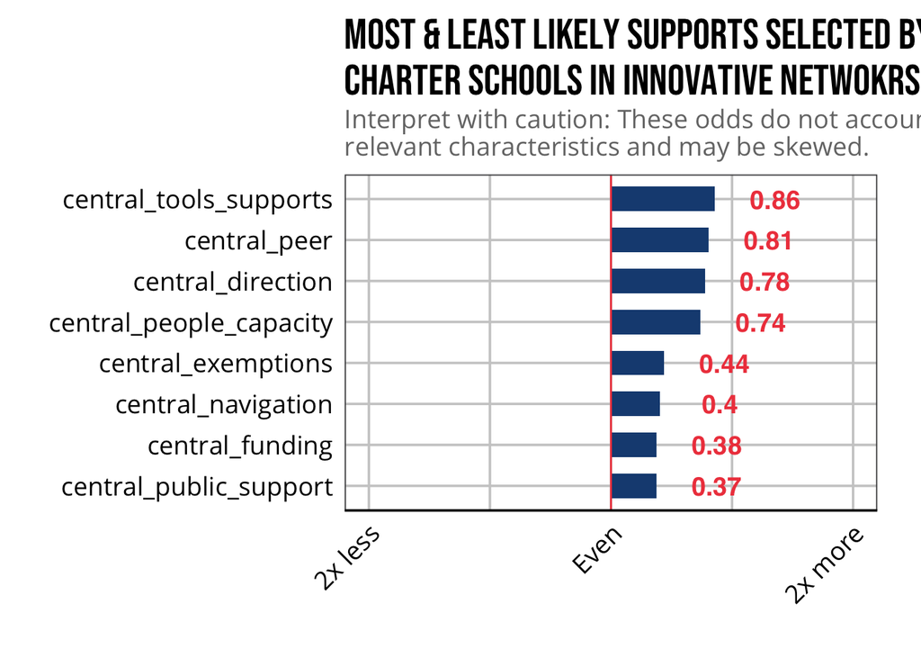

```r
# This isn't working for me! Sad
# It keeps telling me I am missing the by argument in summarize
# I received the same error when trying to run Janette's code

central_odd <- full %>%
  select(starts_with("central_"), innovation_initiative) %>%
  select(-c("central_n_a", "central_other", "central_other_text")) %>%
  filter(innovation_initiative == 1) %>%
  select(-innovation_initiative) %>%
  pivot_longer(cols = starts_with("central_"),
               names_to = "central",
               values_to = "n") %>%
  mutate(central = as.factor(central)) %>%
  group_by(central) %>%
  dplyr::summarize(n = sum(n, na.rm = TRUE))




central_odd_not <- full %>%
  select(starts_with("central_"), innovation_initiative) %>%
  select(-c("central_n_a", "central_other", "central_other_text")) %>%
  filter(innovation_initiative == 0 | innovation_initiative == 2) %>%
  select(-innovation_initiative) %>%
  pivot_longer(cols = starts_with("central_"),
               names_to = "central",
               values_to = "n") %>%
  mutate(central = as.factor(central)) %>%
  group_by(central) %>%
  dplyr::summarize(n = sum(n, na.rm = TRUE))


# EXAMPLE:
##                 Direction   |  No Direction
##
## Inno Network      36             27
##
## No Network        40             112

# Prob of Direction support in Inno Network: 36/63 = 0.57
# Prob of Direction support No Network: 40/ 152 = 0.26
# Odds Ratio: 0.57/0.26 = 2.17
# Log Odds ratio: log(2.17) = 0.775

# THIS IS NOT THE SAME AS THE CODE ABOVE
## I think the code above is assuming that we can calculate the odds ratio by doing the probability -1, but due to NAs in the data that doesn't quite work.


#####################################################################
# Manually calculating odds ratio based on how I understand them

central_odd <- central_odd %>%
  mutate(net_yes = 63,
         prob_yes = n/63)

central_odd_not <- central_odd_not %>%
  mutate(net_no = 152,
         prob_y = n/152)

central_odd <- left_join(central_odd, central_odd_not, by = "central")

central_odd <- central_odd %>%
  mutate(odd = prob_yes/prob_y,
         lor = log(odd)) %>%
    arrange(desc(odd)) %>%
  mutate(likely = case_when(
    lor > 0 ~ "more",
    lor < 0 ~ "less"
  ))

# Now a corresponding graph
########################################################################

ggplot(central_odd, aes(reorder(central, lor), lor, fill = likely)) +
  geom_col() +
  scale_fill_manual(values = transcend_cols[1:2]) +
  labs(title = "Most & Least Likely Supports Selected by\nCharter Schools in Innovative Netwokrs",
       subtitle = "Interpret with caution: These odds do not account for \nrelevant characteristics and may be skewed.",
       x = "",
       y = "") +
  coord_flip() +
  theme(legend.position = "none",
        axis.text.x = element_text(angle = 45, hjust = 1)) +
  scale_y_continuous(limits=c(-2, 2),
                     labels = c("-2" = "2x less",
                                "-1" = "",
                            "0" = "Even",
                            "1" = "",
                            "2" = "2x more")) +
  geom_hline(yintercept = 0, color = transcend_cols[3]) +
  geom_text(aes(label = signif(round(lor, 2))),
            nudge_y = .5,
            color = transcend_cols[3],
            fontface = "bold",
            size = 5,
            family = "sans")
```

```r
########################################################################

table(central_odd$innovation_initiative)
```

```
## < table of extent 0 >
```

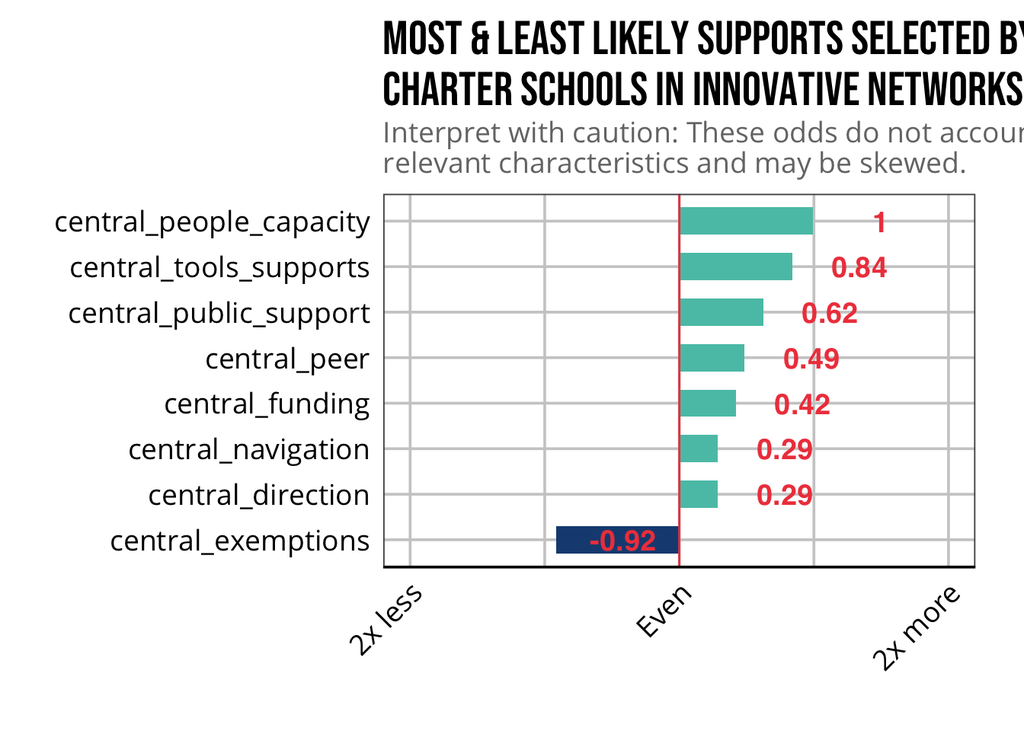

```r
# 0 = 124 (No)
# 1 = 63 (Yes)
# 2 = 28 (Not Sure)
# NA = 36

central_odd_x <- full %>%
  select(starts_with("central_"), innovation_initiative) %>%
  select(-c("central_n_a", "central_other", "central_other_text")) %>%
  filter(innovation_initiative == 1) %>%
  select(-innovation_initiative) %>%
  pivot_longer(cols = starts_with("central_"),
               names_to = "central",
               values_to = "n") %>%
  mutate(central = as.factor(central)) %>%
  group_by(central) %>%
  dplyr::summarize(n = sum(n, na.rm = TRUE)) %>%
  mutate(prob = n/63,
         odds = prob/(1-prob),
         lor = log(odds)) %>%
  arrange(desc(n)) %>%
  mutate(likely = case_when(
    lor > 0 ~ "more",
    lor < 0 ~ "less"
  ))


ggplot(central_odd_x, aes(reorder(central, lor), lor, fill = likely)) +
  geom_col() +
  scale_fill_manual(values = transcend_cols[1:2]) +
  labs(title = "Most & Least Likely Supports Selected by\nCharter Schools in Innovative Networks",
       subtitle = "Interpret with caution: These odds do not account for \nrelevant characteristics and may be skewed.",
       x = "",
       y = "") +
  coord_flip() +
  theme(legend.position = "none",
        axis.text.x = element_text(angle = 45, hjust = 1)) +
  scale_y_continuous(limits=c(-2, 2),
                     labels = c("-2" = "2x less",
                                "-1" = "",
                            "0" = "Even",
                            "1" = "",
                            "2" = "2x more")) +
  geom_hline(yintercept = 0, color = transcend_cols[3]) +
  geom_text(aes(label = signif(round(lor, 2))),
            nudge_y = .5,
            color = transcend_cols[3],
            fontface = "bold",
            size = 5,
            family = "sans")
```

**I think I made a mistake**  
The odds Ratios are different in this version.

*Odds Ratios without Not sure and NA*

Odds Ratios:  
Direction 4.98 p < 0.001  
Exemptions 1.75 p = 0.14  
Funding 2.48 p = 0.005  
Navigation 2.59 p = 0.003  
Peer Connection 4.44 p < 0.001  
People Capacity 5.84 p < 0.001  
Public Support 2.93 p =0.001  
Curriculum 7.16 p < 0.001

**UPDATED** Odds Ratios: Without NAs for Innovation Network and grouping No Support and No  
Schools in the Innovation Network were 3.71 times more likely to report central support in direction, p < 0.001

Schools in the Innovation Network were 1.77 times more likely to report central support in exemptions, p = 0.10

Schools in the Innovation Network were 2.14 times more likely to report central support in funding, p = 0.016

Schools in the Innovation Network were 2.15 times more likely to report central support in navigation, p = 0.015

Schools in the Innovation Network were 4.22 times more likely to report central support in peer connections, p < 0.001

Schools in the Innovation Network were 5.01 times more likely to report central support in people capacity and time, p < 0.001

Schools in the Innovation Network were 2.29 times more likely to report central support in public support, p = 0.007

Schools in the Innovation Network were 5.46 times more likely to report central support in curriculum and tools, p < 0.001

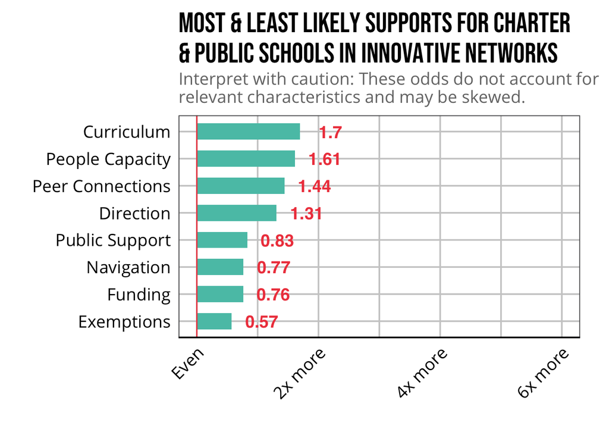

```r
odds = c(3.71, 1.77, 2.14, 2.15, 4.22, 5.01, 2.29, 5.46)
lor <- log(odds)

central_odds <- data.frame(odds = c(3.71, 1.77, 2.14, 2.15, 4.22, 5.01, 2.29, 5.46),
                           p_value = c(0.001, 0.10, 0.016, 0.015, 0.001, 0.001, 0.007, 0.001),
                           lor = lor,
                           supports = c("Direction", "Exemptions", "Funding", "Navigation", "Peer Connections", "People Capacity", "Public Support", "Curriculum"))

#plot
central_odds %>%
  ggplot(aes(reorder(supports, lor), lor)) +
  geom_col(fill = "#59C3B4") +
  theme(legend.position = "none",
        axis.text.x = element_text(angle = 45, hjust = 1)) +
  coord_flip() +
  labs(title = "Most & Least Likely Supports for Charter \n& Public Schools in Innovative Networks",
       subtitle = "Interpret with caution: These odds do not account for \nrelevant characteristics and may be skewed.",
       x = "",
       y = "") +
  scale_y_continuous(limits=c(0, 6),
                     labels = c(
                            "0" = "Even",
                            "1" = "",
                            "2" = "2x more",
                            "3" = "",
                            "4" = "4x more",
                            "5" = "",
                            "6" = "6x more"),
                     n.breaks = 7) +
  geom_hline(yintercept = 0, color = transcend_cols[3]) +
  geom_text(aes(label = round(lor, 2)),
             nudge_y = .5,
             color = transcend_cols[3],
             fontface = "bold",
             size = 5,
            family = "sans")
```

### Write Up

So here is the deal. I am a little lost. I can’t figure out how this is suppose to look. When I use the fisher test to get my odds ratios it is different than if I calculate it myself.

I am not sure I fully understand the fisher test so it might make sense to use calculated odds ratios even though they would not have significance values. The chi squared test can tell us that the difference between the two groups are statistically significant.

I checked the contingency tables to ensure they were really calculating without NA values for innovative network and indeed they are the same as the tables I had calculated by hand. In this I grouped unsure and no support as both no support for being in an innovative network.

I am inclined to use the odds ratios calculated by hand.

Here is the graph based on the hand calculated odds ratios and the datatable for it:

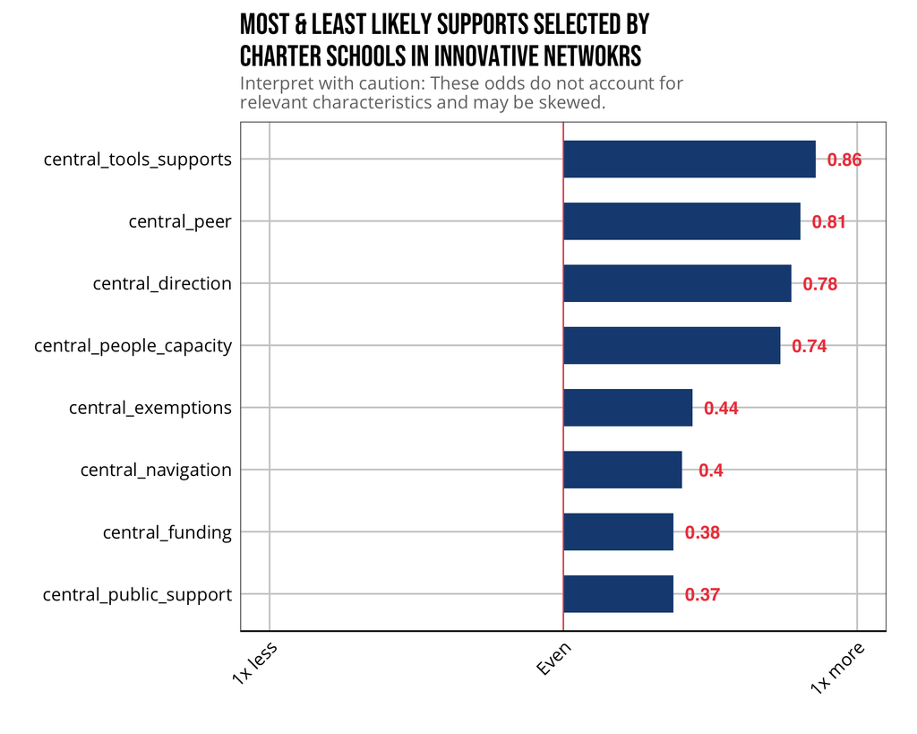

```r
ggplot(central_odd, aes(reorder(central, lor), lor, fill = likely)) +
  geom_col() +
  scale_fill_manual(values = transcend_cols[1:2]) +
  labs(title = "Most & Least Likely Supports Selected by\nCharter Schools in Innovative Netwokrs",
       subtitle = "Interpret with caution: These odds do not account for \nrelevant characteristics and may be skewed.",
       x = "",
       y = "") +
  coord_flip() +
  theme(legend.position = "none",
        axis.text.x = element_text(angle = 45, hjust = 1)) +
  scale_y_continuous(limits=c(-1, 1),
                     labels = c("-1" = "1x less",
                            "0" = "Even",
                            "1" = "1x more"),
                     n.breaks = 3) +
  geom_hline(yintercept = 0, color = transcend_cols[3]) +
  geom_text(aes(label = signif(round(lor, 2))),
            nudge_y = .1,
            color = transcend_cols[3],
            fontface = "bold",
            size = 5,
            family = "sans")
```

```r
central_odd <- central_odd %>%
  mutate(supp_yes = n.x,
         net_yes = net_yes,
         prob_supp_net =round(prob_yes,2),
         supp_no = n.y,
         net_no = net_no,
         prob_supp_no = round(prob_y,2),
         odd_ratio = round(odd,2),
         log_or = round(lor,2),
         likely = likely) %>%
  select(c(central, supp_yes, net_yes, prob_supp_net, supp_no, net_no, prob_supp_no, odd_ratio, log_or, likely))

gt(central_odd)
```

| central | supp_yes | net_yes | prob_supp_net | supp_no | net_no | prob_supp_no | odd_ratio | log_or | likely |
| --- | --- | --- | --- | --- | --- | --- | --- | --- | --- |
| central_tools_supports | 44 | 63 | 0.70 | 45 | 152 | 0.30 | 2.36 | 0.86 | more |
| central_peer | 39 | 63 | 0.62 | 42 | 152 | 0.28 | 2.24 | 0.81 | more |
| central_direction | 36 | 63 | 0.57 | 40 | 152 | 0.26 | 2.17 | 0.78 | more |
| central_people_capacity | 46 | 63 | 0.73 | 53 | 152 | 0.35 | 2.09 | 0.74 | more |
| central_exemptions | 18 | 63 | 0.29 | 28 | 152 | 0.18 | 1.55 | 0.44 | more |
| central_navigation | 36 | 63 | 0.57 | 58 | 152 | 0.38 | 1.50 | 0.40 | more |
| central_funding | 38 | 63 | 0.60 | 63 | 152 | 0.41 | 1.46 | 0.38 | more |
| central_public_support | 41 | 63 | 0.65 | 68 | 152 | 0.45 | 1.45 | 0.37 | more |

## Indepdent schools

How do schools’ responses to the “how important is this network” question relate to their responses to the “does your network provide” question?